# Mixture Hidden Markov Model for Poverty Measurement using Longitudinal Data

Markov modelling presents an analytical framework for modeling state switching processes occuring with an individual or within a family unit using panel study longitudinal data. Income mobility and poverty switching dynamics particularly have generated some interest in the economics/social policy field. Similar to the analysis of Costa and Angelis, in this paper, I am trying to model the switching states of poverty. They postulate that there are two underlying poverty states; *transitionary* and *permenent*. I aim to discover these states using the data from the Panel Study of Income Dynamics run by the Institute of Social Research at the University of Michigan.

### The Data

The panel study of income dynamics (PSID) is a long running longitudinal household survey which began in 1968. It studies a nationally representative sample of over 18000 individuals living in 5000 families in the United States. The design of the survey, interviewing both individuals and family units over time, presents an interesting opportunity to study poverty transition by family unit. The poverty proxy used in this analysis takes the median of the Total Income variable - similar to the process used by Costa and Angelis - and keeps only those indivials below the median level. I also use socio-economic indicators from the data as transition covariates in the HMM model. Specifically, the *age*, *employment status*, *years of education completed* and *race* variables. Costa and Angelis use the same covariates with the inclusion of *housing htatus*, *gender* and *geographical area*. Gender was not included in the HMM model in this analysis as this is an individual level variable that does not apply to the family as a unit of observation. Below is a break down of the specific variables used, transformations to the variables, as well as year of waves. Years: For this analysis I have used 6 waves of the study, 2005, 2007, 2009, 2011, 2013 and 2015. After excluding families over the median level of income, and dropping observations with non-responses in any of the covariates, the number of observations in each wave are as follows.

| Year of study | 2005 | 2007 | 2009 | 2011 | 2013 | 2015 |
| --- | --- | --- | --- | --- | --- | --- |
| No. of observations | 17033 | 15767 | 14324 | 14185 | 12857 | 11078 |

These numbers were inclded in the model to account for the cycles of the longitudinal dataset.

**Employment Status:** This variable was derived using the ‘Employment Status’ sequence of questions. The data is coded as *Employed* if a responded answered `1 - Working Now`, *Unemployed* if the respondent answered `2 - Temporarily laid off`, `3 - Looking for work, unemployed`, `6 - Housewife`, coded Retired if the respondent answered `4 - Retired` and and coded *Other* for everything else.

**Years of Education Completed:** This is another continuous variable with years of education completed in lifetime of respondent. The range of this variable is 0 - 12 with 99 for respondents who refused to reply. All observtions with a response of 99 were coded as missing and dropped from the analysis.

**Race:** This variable was derived as the combination of two response variables from the data. The race of the head of household and the race of spouse. If the head and spouse have the same race, the family unit is coded as that race. If the head of household and spouse are of different races, the *Race* variable was coded as other. Due to the different combinations of races, more than 10, assigning dummy variables to all the mixed race families was not feasible. All the major race categories were preserved.

**Total Income:** Total household income in dollars reported by respondents. This income level is the same for all individuals in the household.

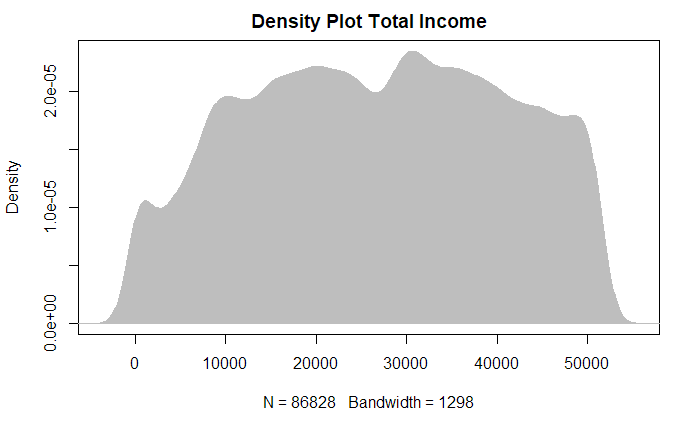

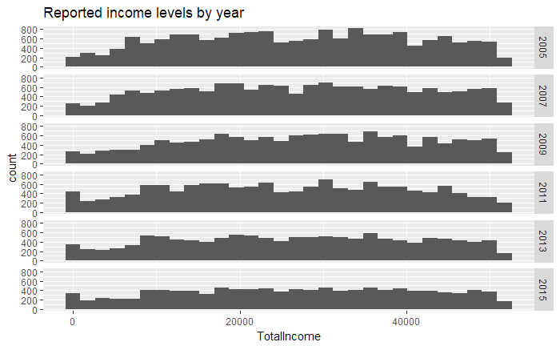

Model For this analysis, I used a hidden markov model which is defined by the following:
$$\begin{array}{l} f_{X_{0}}(x_0\params\theta), \ f_{X_{n}|X_{n-1}}(x_{n}\given x_{n-1}\params\theta), \ f_{Y_{n}|X_n}(y_{n}\given x_n\params\theta), \end{array}$$
for $n=1:N$ Here I assume that family has a latent rate $X_i(t)$ of transitiong out or back into poverty states. Each data point $y_{ij}$ is the total income level for a family between time $t_{j-1}$ and $t_j$, where $i=1,\dots,85244$ and $j=1,\dots,6$. The unobserved poverty process $\{X_i(t)\}$ is connected to the data through change in income for each family unit $i$ in number of reporting cycles $j$, which can be written as
$$C_{ij}= \int_{t_{j-1}}^{t_j} X_i(t)\, dt,$$
. [2]
A stochastic mixture model for gaussian distributed data was used to model $y_{ij}$ as a gaussian random variable with mean $\mu$ and variance $\sigma^2$. This model was chosen after examining the vizually density of the response variable and testing the fit of different distributions to the data and comparing AIC. The distributions tested were **lognormal**, **normal**, **weibull** and **gamma**. Only the **lognormal** and **gaussian** distributions could be fitted to the data, and Like the plot suggests, the data is best fit by a normal/gaussian model as it had the lower AIC of `1904573` compared to `2032992` with the lognormal. The Mixture Hidden Markov Model(MHMM) was selected for this analysis vs the Partially Observed Markov Model (POMP) because it allows for a continuous gaussian distributed response variable which a POMP does not. The possibility of a general dependence on $n$ includes the possibility that there is some covariate time series $z_{0:N}$ such that
$$\begin{array}{lcl} f_{X_{0}}(x_0\params\theta)&=& f_{X_{0}}(x_0\params\theta,z_0) \ f_{X_{n}|X_{n-1}}(x_{n}\given x_{n-1}\params\theta) &=& f_{X_{n}|X_{n-1}}(x_{n}\given x_{n-1}\params\theta,z_n), \ f_{Y_{n}|X_n}(y_{n}\given x_n\params\theta) &=& f_{Y_{n}|X_n}(y_{n}\given x_n\params\theta,z_n), \end{array}$$
for $n=1:N$
To derive a multidimensional concept of poverty, the covariates **age**, **years of education**, **employment status** and **race** were included in the model as I hypothesized these soci-economic factors to have an effect on the transition of poverty states. To test this hypothesis, I ran a glm regression on the response variable **total income** using the covariates as independent variables (see analysis section). The regression Parameter estimation for the MHMM model was achieved by means of a variant of the EM procedure, forward-backward or Baum-Welch algorithm.

Analysis First, after using a glm regression to the hypothesis of a relationship between total income levels and the four independent variables, I found age, as well as employment status to be statistically significant. The difference income levels between white households compared to black and american indian households was also statistically significant. Note that these households are households below the median income levels overall. Years completed education is not significant but the model including it as a transition covariate performed better in terms of log likelihood, AIC and BIC values (Table 1).

```
Call:
glm(formula = log(TotalIncome) ~ Age + as.factor(EmploymentStatus) +
    as.factor(Race) + YearsCompletedEducation, data = PSIDdat)

Deviance Residuals:
     Min        1Q    Median        3Q       Max
-12.6766   -0.2183    0.2954    0.6621    1.7196

Coefficients:
                                          Estimate Std. Error t value Pr(>|t|)
(Intercept)                             10.0168328  0.0103971 963.422  < 2e-16 ***
Age                                     -0.0022776  0.0003552  -6.411 1.45e-10 ***
as.factor(EmploymentStatus)Employed      0.3887984  0.0165892  23.437  < 2e-16 ***
as.factor(EmploymentStatus)Unemployed   -0.3289443  0.0201588 -16.318  < 2e-16 ***
as.factor(EmploymentStatus)Retired       0.1603831  0.0303615   5.282 1.28e-07 ***
as.factor(Race)Other                     0.0231736  0.0210058   1.103    0.270
as.factor(Race)Black/African-American   -0.4039575  0.0110886 -36.430  < 2e-16 ***
as.factor(Race)American Indian          -0.4215158  0.0618219  -6.818 9.28e-12 ***
as.factor(Race)Asian                    -0.0191417  0.0554854  -0.345    0.730
as.factor(Race)Native Hawaiian/Islander  0.2628725  0.4071302   0.646    0.518
YearsCompletedEducation                  0.0008535  0.0008495   1.005    0.315
---
Signif. codes:  0 ‘***’ 0.001 ‘**’ 0.01 ‘*’ 0.05 ‘.’ 0.1 ‘ ’ 1

(Dispersion parameter for gaussian family taken to be 2.319653)

    Null deviance: 205549  on 85243  degrees of freedom
Residual deviance: 197711  on 85233  degrees of freedom
AIC: 313651

Number of Fisher Scoring iterations: 2
```

I also examined the autocorrelation between the two continuous covariates and income levels using a CCF plot of each and found evidence for autocorrelation at different lag periods.

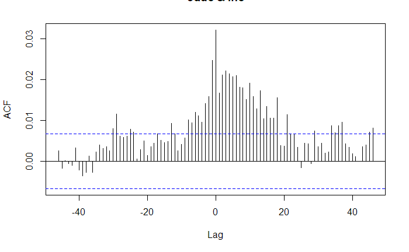

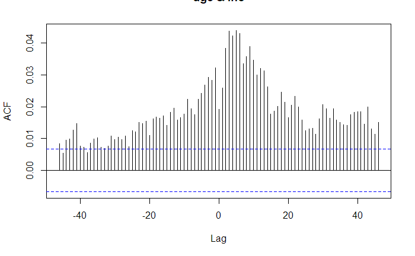

Table 1

| States | Log.Lik | AIC | BIC | df | Response | Covariates |
| --- | --- | --- | --- | --- | --- | --- |
| 2 | -922865.3 | 1845773 | 1845969 | 21 | Total Income | Race, Age, Years of Education |
| 3 | -934894.0 | 1869900 | 1870424 | 56 | Total Income | Race, Age, Years of Education |
| 4 | -934894.0 | 1870002 | 1871003 | 107 | Total Income | Race, Age, Years of Education |
| 2 | -1028984.0 | 2057994 | 2058115 | 13 | Total Income and Employment Status | None |
| 2 | -934894.0 | 1869842 | 1870095 | 27 | Total Income | Race, Age, Years of Education, Years of Employment |
| 3 | -934894.0 | 1869816 | 1869947 | 14 | Total Income | None |
| 2 | -934894.0 | 1869826 | 1870004 | 19 | Total Income | Race and Age |
| 3 | -934894.0 | 1869888 | 1870356 | 50 | Total Income | Race and Age |

## Results and Discussion

Because the algorithm allows covariates on the transition probabilities, the default baseline category is the first state. The probability of being in the first state is the second state value in the first component, and the probability of being in the second state is the second state value in the second state component. We can also see the probability of being in each state withing each state component when the covariates are set at 0. (See table below)

Table 2

| Covariates | State Component 1 State.1.1 | State Component 1 State.1.2 | State Component 2 State.2.1 | State Component 2 State.2.2 |
| --- | --- | --- | --- | --- |
| (Intercept) | 0.0000000 | -1.6952652 | 0.000000 | 1.6539263 |
| RaceWhite | 0.0000000 | 0.3452791 | 0.000000 | -0.1616289 |
| RaceBlack/African-American | 0.0000000 | -0.0162066 | 0.000000 | -0.8061333 |
| RaceAmerican Indian | 0.0000000 | 0.4283429 | 0.000000 | -0.6587425 |
| RaceAsian | 0.0000000 | -0.3316479 | 0.000000 | 0.3998702 |
| RaceNative Hawaiian/Islander | 0.0000000 | 0.0955277 | 0.000000 | -0.4882065 |
| Age | 0.0000000 | 0.0094510 | 0.000000 | -0.0065010 |
| YearsCompletedEducation | 0.0000000 | 0.0057672 | 0.000000 | -0.0049468 |
| Probalities at zero values of the covariates | 0.8449153 | 0.1550847 | 0.160579 | 0.8394210 |

To analyze the state for each individual in a household, and compare it to the covariates, we use the posterior viterbi algorithm to find the most likely state sequence. We vizualize the most probable state for each household and analyze the result. Looking at the results, there are clear indications that state 1 is the permanent poverty state, and state 2 is the transitionary poverty state. We can see some interesting results looking at charts 1 and 2. It seems like white and mixed households on average, are less likely to be in the permanent poverty state than black households. It also seems (chart 2), that households where the head of house and spouse are employed are more likely to be in the transtionary poverty state than households with unemployed individuals. Looking also at income levels by state, we can see that households with higher income levels are overwhelmenly more likely to be in the transitionary poverty state than those with lower income levels. For the age covariate, on average, younger individuals are more likely to be in a permanent poverty state,but the difference is trivial.

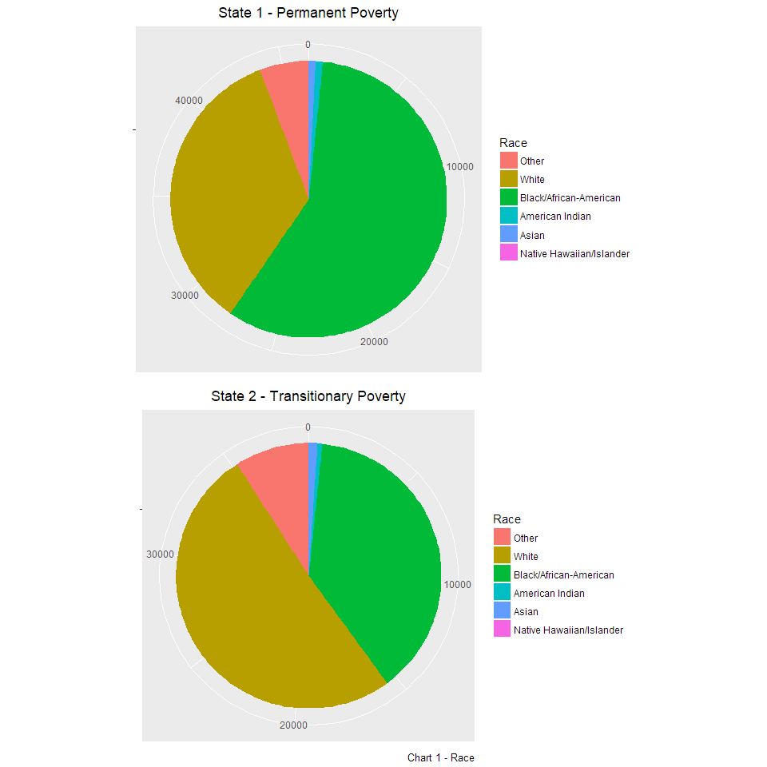

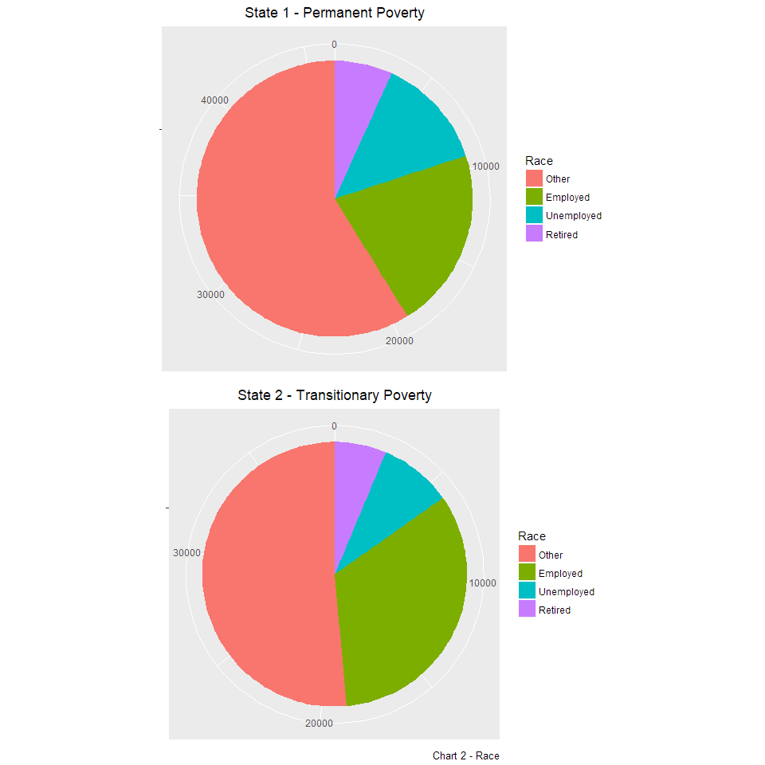

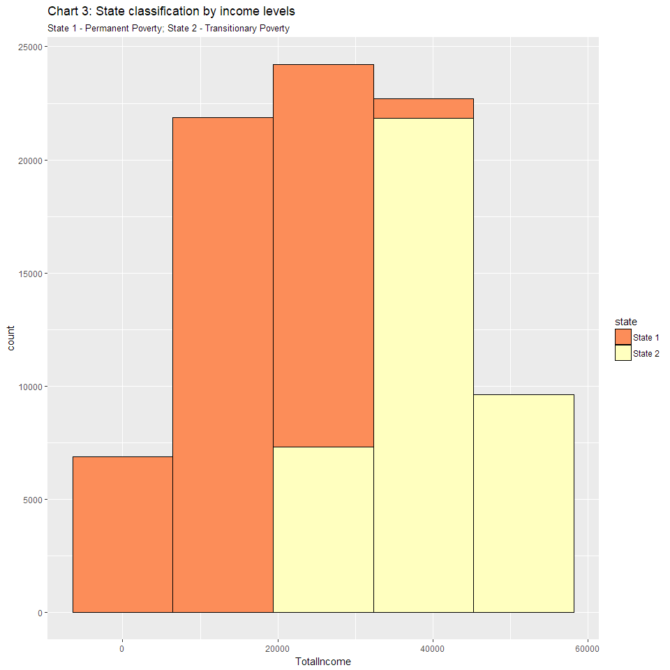

[figure not shown]

## References

A Dynamic Latent Model for Poverty Measurement; Michelle Costa and Luca De Angelis  
Panel Study of Income Dynamics (PSID) University of Michigan  
https://pdfs.semanticscholar.org/207e/81cf7b5c22176ae3972da2ecd09f6b2c3c67.pdf  
http://yunus.hacettepe.edu.tr/~iozkan/eco742/hmm.html Lecture Notes: https://ionides.github.io/531w18/13/notes13.html  
Depmix4 CRAN